# Homework Assignment 1

Sanchi Goel

Assigned: Oct 24, 2020, Due Sun Nov 01, 2020 11:59PM

### Data frame basics

```r
nyc <- read.csv('nycflights.csv')
nyc$carrier <- as.factor(nyc$carrier)
nyc$tailnum <- as.factor(nyc$tailnum)
nyc$origin <- as.factor(nyc$origin)
nyc$dest <- as.factor(nyc$dest)
nyc$X <- NULL
str(nyc)
```

```
## 'data.frame':    336776 obs. of  19 variables:
##  $ year          : int  2013 2013 2013 2013 2013 2013 2013 2013 2013 2013 ...
##  $ month         : int  1 1 1 1 1 1 1 1 1 1 ...
##  $ day           : int  1 1 1 1 1 1 1 1 1 1 ...
##  $ dep_time      : int  517 533 542 544 554 554 555 557 557 558 ...
##  $ sched_dep_time: int  515 529 540 545 600 558 600 600 600 600 ...
##  $ dep_delay     : int  2 4 2 -1 -6 -4 -5 -3 -3 -2 ...
##  $ arr_time      : int  830 850 923 1004 812 740 913 709 838 753 ...
##  $ sched_arr_time: int  819 830 850 1022 837 728 854 723 846 745 ...
##  $ arr_delay     : int  11 20 33 -18 -25 12 19 -14 -8 8 ...
##  $ carrier       : Factor w/ 16 levels "9E","AA","AS",..: 12 12 2 4 5 12 4 6 4 2 ...
##  $ flight        : int  1545 1714 1141 725 461 1696 507 5708 79 301 ...
##  $ tailnum       : Factor w/ 4043 levels "D942DN","N0EGMQ",..: 180 524 2401 3204 2661 1142 1829 3300 2207 1178 ...
##  $ origin        : Factor w/ 3 levels "EWR","JFK","LGA": 1 3 2 2 3 1 1 3 2 3 ...
##  $ dest          : Factor w/ 105 levels "ABQ","ACK","ALB",..: 44 44 59 13 5 70 36 43 55 70 ...
##  $ air_time      : int  227 227 160 183 116 150 158 53 140 138 ...
##  $ distance      : int  1400 1416 1089 1576 762 719 1065 229 944 733 ...
##  $ hour          : int  5 5 5 5 6 5 6 6 6 6 ...
##  $ minute        : int  15 29 40 45 0 58 0 0 0 0 ...
##  $ time_hour     : chr  "2013-01-01 05:00:00" "2013-01-01 05:00:00" "2013-01-01 05:00:00" "2013-01-01 05:00:00" ...
```

### Data Exploration

There are 16 airlines

Following is a list: 9E, AA, AS, B6, DL, EV, F9, FL, HA, MQ, OO, UA, US, VX, WN, YV

No. of airlines with the code’OO’ are: 32

The shortest flight out of any NYC airport is 20

No. of flights with code “UA” on Jan 12th 2013 were 112

### Arrival Delay

Average arrival delay for all airports and all airlines combined in Jan 2013 was 6.13 minutes.

The median arrival delay for all airports and all airlines combined in Jan 2013 was -3 minutes.

Most flights arrive earlier than expected however some flights have a large delay leading to the positive mean.

### Airline Performance

#### Average arrival delays by airlines:

```r
delayair <- round(tapply(nyc$arr_delay, nyc$carrier, mean, na.rm=TRUE),2)
delayair
```

```
##    9E    AA    AS    B6    DL    EV    F9    FL    HA    MQ    OO    UA    US
##  7.38  0.36 -9.93  9.46  1.64 15.80 21.92 20.12 -6.92 10.77 11.93  3.56  2.13
##    VX    WN    YV
##  1.76  9.65 15.56
```

#### BarPlot of Arrival Delays

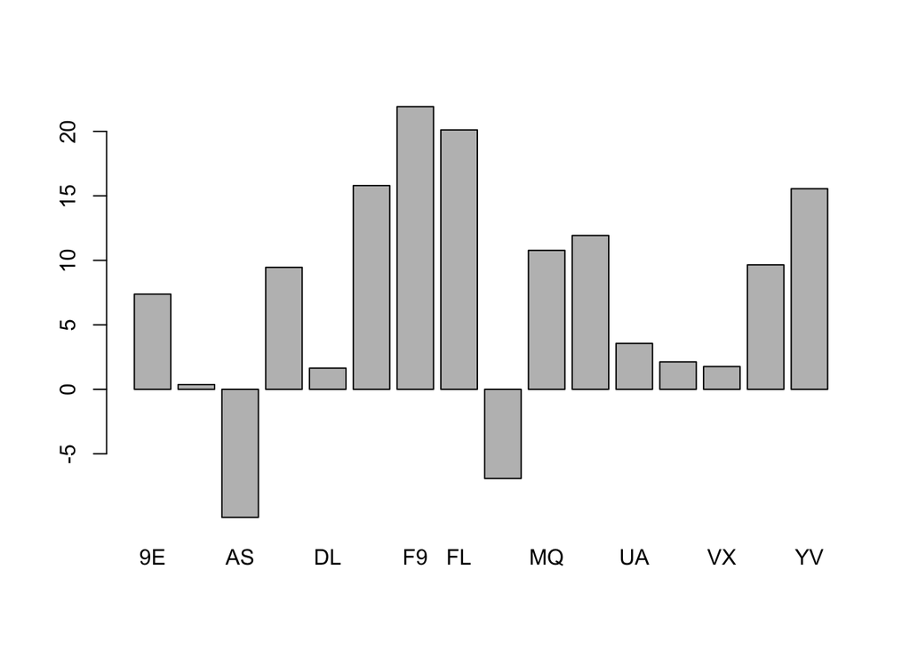

```r
barplot((tapply(nyc$arr_delay, nyc$carrier, mean, na.rm=TRUE))
)
```

F9 has the highest average delay of 21.9207048 minutes.

AS has the smallest average arrival delay of -9.9308886 minutes.

Both AS and HA have negative arrival delays meaning they arrive early on average.

### Air Gain

```r
nyc$airgain <- nyc$dep_delay - nyc$arr_delay
```

#### Descriptive Statistics of Airgain

```r
summary(nyc$airgain)
```

```
##    Min. 1st Qu.  Median    Mean 3rd Qu.    Max.    NA's
## -196.00   -3.00    7.00    5.66   17.00  109.00    9430
```

#### Summary Graphics

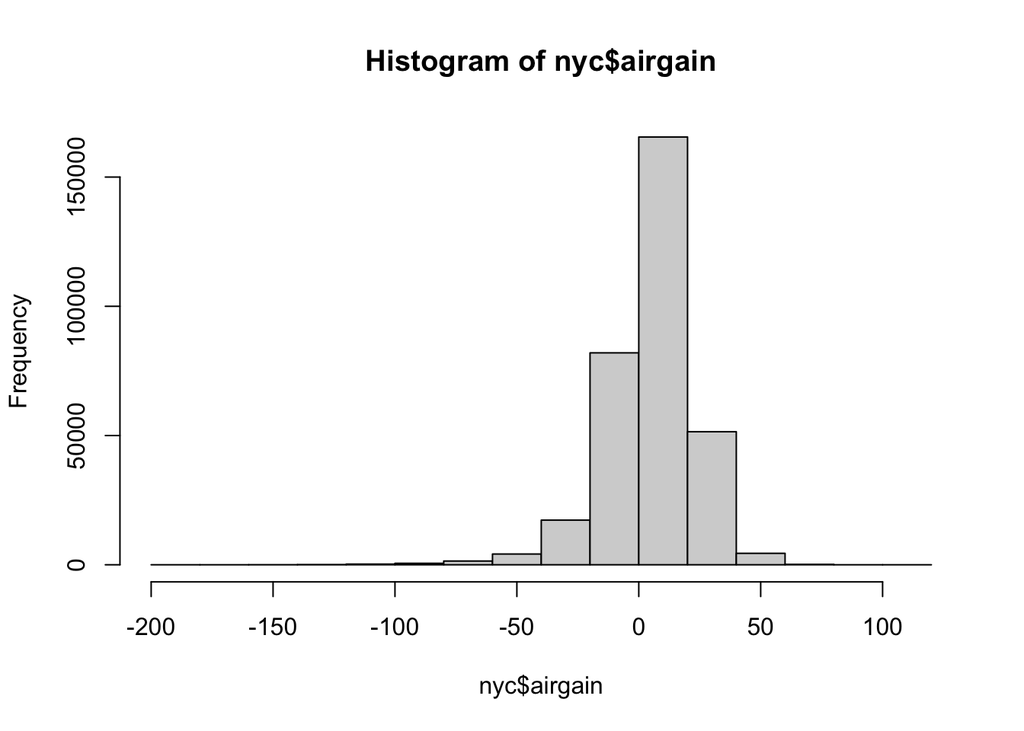

```r
hist(nyc$airgain)
```

Airlines gain 5.6 minutes on average.

#### Average Airgain for Airlines:

```r
tapply(nyc$airgain, nyc$carrier, mean, na.rm=TRUE)
```

```
##         9E         AA         AS         B6         DL         EV         F9
##  9.0599052  8.2048393 15.7616361  3.5095746  7.5796089  4.0424982 -1.7195301
##         FL         HA         MQ         OO         UA         US         VX
## -1.5099213 11.8157895 -0.3293526  0.6551724  8.4588972  1.6150976 10.9921814
##         WN         YV
##  8.0125374  3.3419118
```

F9 and FL do the worst job whereas HA and AS do the best.

### Merging Data Frames

#### Data Cleaning

```r
planes <- read.csv('planes.csv')
planes$X <- NULL
planes$tailnum <- as.factor(planes$tailnum)
planes$type <- as.factor(planes$type)
planes$engine <- as.factor(planes$engine)
planes$model <- as.factor(planes$model)
planes$year <- as.factor(planes$year)
planes$seats <- as.factor(planes$seats)
planes$engines <- as.factor(planes$engines)
planes$manufacturer <- as.factor(planes$manufacturer)
str(planes)
```

```
## 'data.frame':    3322 obs. of  9 variables:
##  $ tailnum     : Factor w/ 3322 levels "N10156","N102UW",..: 1 2 3 4 5 6 7 8 9 10 ...
##  $ year        : Factor w/ 46 levels "1956","1959",..: 37 31 32 32 35 32 32 32 32 32 ...
##  $ type        : Factor w/ 3 levels "Fixed wing multi engine",..: 1 1 1 1 1 1 1 1 1 1 ...
##  $ manufacturer: Factor w/ 35 levels "AGUSTA SPA","AIRBUS",..: 18 3 3 3 18 3 3 3 3 3 ...
##  $ model       : Factor w/ 127 levels "150","172E","172M",..: 108 87 87 87 107 87 87 87 87 87 ...
##  $ engines     : Factor w/ 4 levels "1","2","3","4": 2 2 2 2 2 2 2 2 2 2 ...
##  $ seats       : Factor w/ 48 levels "2","4","5","6",..: 15 30 30 30 15 30 30 30 30 30 ...
##  $ speed       : int  NA NA NA NA NA NA NA NA NA NA ...
##  $ engine      : Factor w/ 6 levels "4 Cycle","Reciprocating",..: 3 3 3 3 3 3 3 3 3 3 ...
```

#### Merging Data Frames

```r
merged <- merge(nyc, planes, by.x="tailnum", by.y = "tailnum", sort=TRUE)
str(merged)
```

```
## 'data.frame':    284170 obs. of  28 variables:
##  $ tailnum       : Factor w/ 4043 levels "D942DN","N0EGMQ",..: 3 3 3 3 3 3 3 3 3 3 ...
##  $ year.x        : int  2013 2013 2013 2013 2013 2013 2013 2013 2013 2013 ...
##  $ month         : int  8 1 1 1 2 9 3 3 11 6 ...
##  $ day           : int  12 17 23 10 17 23 12 20 3 11 ...
##  $ dep_time      : int  1312 1213 746 626 NA 1008 2000 2216 1218 1911 ...
##  $ sched_dep_time: int  1317 1218 645 630 1415 1015 2000 2100 1226 1911 ...
##  $ dep_delay     : int  -5 -5 61 -4 NA -7 0 76 -8 0 ...
##  $ arr_time      : int  1528 1422 852 802 NA 1117 2234 13 1404 2124 ...
##  $ sched_arr_time: int  1528 1415 757 800 1616 1139 2245 2315 1418 2115 ...
##  $ arr_delay     : int  0 7 55 2 NA -22 -11 58 -14 9 ...
##  $ carrier       : Factor w/ 16 levels "9E","AA","AS",..: 6 6 6 6 6 6 6 6 6 6 ...
##  $ flight        : int  4304 4641 4241 4560 4229 4187 4204 3817 4640 4397 ...
##  $ origin        : Factor w/ 3 levels "EWR","JFK","LGA": 1 1 1 1 1 1 1 1 1 1 ...
##  $ dest          : Factor w/ 105 levels "ABQ","ACK","ALB",..: 63 24 29 76 22 11 68 89 28 54 ...
##  $ air_time      : int  171 111 47 60 NA 105 193 101 92 157 ...
##  $ distance      : int  1167 529 199 319 628 748 1325 642 533 1092 ...
##  $ hour          : int  13 12 6 6 14 10 20 21 12 19 ...
##  $ minute        : int  17 18 45 30 15 15 0 0 26 11 ...
##  $ time_hour     : chr  "2013-08-12 13:00:00" "2013-01-17 12:00:00" "2013-01-23 06:00:00" "2013-01-10 06:00:00" ...
##  $ airgain       : int  -5 -12 6 -6 NA 15 11 18 6 -9 ...
##  $ year.y        : Factor w/ 46 levels "1956","1959",..: 37 37 37 37 37 37 37 37 37 37 ...
##  $ type          : Factor w/ 3 levels "Fixed wing multi engine",..: 1 1 1 1 1 1 1 1 1 1 ...
##  $ manufacturer  : Factor w/ 35 levels "AGUSTA SPA","AIRBUS",..: 18 18 18 18 18 18 18 18 18 18 ...
##  $ model         : Factor w/ 127 levels "150","172E","172M",..: 108 108 108 108 108 108 108 108 108 108 ...
##  $ engines       : Factor w/ 4 levels "1","2","3","4": 2 2 2 2 2 2 2 2 2 2 ...
##  $ seats         : Factor w/ 48 levels "2","4","5","6",..: 15 15 15 15 15 15 15 15 15 15 ...
##  $ speed         : int  NA NA NA NA NA NA NA NA NA NA ...
##  $ engine        : Factor w/ 6 levels "4 Cycle","Reciprocating",..: 3 3 3 3 3 3 3 3 3 3 ...
```

### Interesting Questions

1. Who are the top 10 manufacturers of planes that fly out of NYC airports?

```r
library(plyr)
man_freq <- count(merged, 'manufacturer')
man_freq <- man_freq[order(-man_freq$freq),]
man_freq[1:10,]
```

```
##                     manufacturer  freq
## 10                        BOEING 82912
## 18                       EMBRAER 66068
## 2                         AIRBUS 47302
## 3               AIRBUS INDUSTRIE 40891
## 11                BOMBARDIER INC 28272
## 29 MCDONNELL DOUGLAS AIRCRAFT CO  8932
## 28             MCDONNELL DOUGLAS  3998
## 12                      CANADAIR  1594
## 30 MCDONNELL DOUGLAS CORPORATION  1259
## 14                        CESSNA   658
```

2. Is a particular carrier associated more with the most popular manufacturer Boeing?

```r
boeing <- merged[merged$manufacturer=="BOEING",]
boeing_carrier <- count(boeing, 'carrier')
boeing_carrier <- boeing_carrier[order(-boeing_carrier$freq),]
boeing_carrier
```

```
##   carrier  freq
## 5      UA 40785
## 3      DL 20773
## 7      WN 12237
## 1      AA  5208
## 4      FL  3052
## 2      AS   714
## 6      US   143
```

3. Does the age of the aircraft have any relationship with average distance travelled?

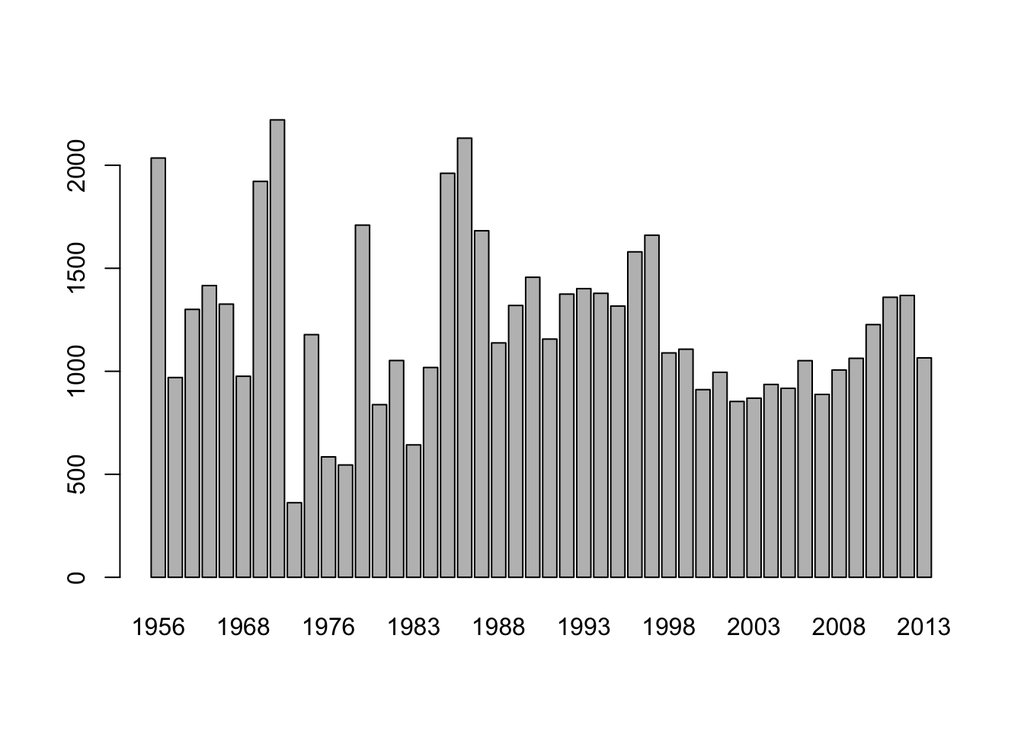

```r
barplot(tapply(merged$distance, merged$year.y, mean, na.rm=TRUE))
```

We can clearly see that the maximum average distances are covered by older planes (1990 and older)

4. Does the number of engines affect the distance covered?

```r
tapply(merged$distance, merged$engines, median, na.rm=TRUE)
```

```
##    1    2    3    4
## 1005  937  544  427
```

Median distance covered sharply decreases as the number of engines increase.

5. What is the most common engine-type for planes flying out of NYC?

```r
table(merged$engine)
```

```
##
##       4 Cycle Reciprocating     Turbo-fan     Turbo-jet    Turbo-prop
##            48          1774        240915         40976            47
##   Turbo-shaft
##           410
```

The most common engine is Turbo-fan.